# Survival plots in Python

# Kaplan-Meier curve using *lifelines*

We can have greater control over the KM curve using the *lifelines* package. This package follows the coding style of packages like *scikit-learn* in that we first start a fitting object, then we fit the model to the data and then plot it

This plotting uses a matplotlib backend

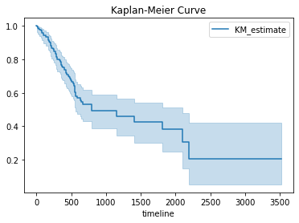

```python
from lifelines import KaplanMeierFitter

kmf = KaplanMeierFitter() # Kaplan Meier fitting object
kmf.fit(time_event, event_observed=censoring) # Fit model to data

kmf.plot(at_risk_counts=False) # No table at first
plt.title('Kaplan-Meier Curve')
plt.show();
```

# Kaplan-Meier curve using *lifelines*

We can clean this curve up a bit.

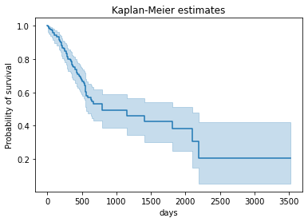

```python
ax = kmf.plot()
ax.set_xlabel('days')
ax.set_ylabel('Probability of survival')
ax.get_legend().remove()
ax.set_title('Kaplan-Meier estimates')
plt.show();
```

## Kaplan-Meier curve using _lifelines

We can also add the table of deaths below the curve.

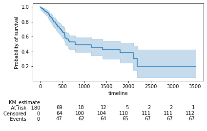

```python
ax = kmf.plot( at_risk_counts=True, legend=False)
ax.set_label('days')
ax.set_ylabel('Probability of survival')
plt.show();
```

## Kaplan-Meier curve using _lifelines

We can also add the table of deaths below the curve, even in grouped data

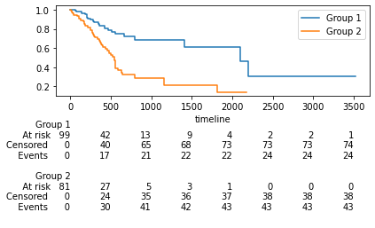

```python
from lifelines.plotting import add_at_risk_counts

T1 = df.query('group==1')['time']
T2 = df.query('group==2')['time']

C1 = df.query('group==1')['Died']
C2 = df.query('group==2')['Died']

fig, ax = plt.subplots()
kmf1 = KaplanMeierFitter()
kmf1.fit(T1, C1,label='Group 1',)
kmf2 = KaplanMeierFitter()
kmf2.fit(T2, C2,label = 'Group 2',)

ax = kmf1.plot_survival_function(ax = ax,  ci_show=False)
ax = kmf2.plot_survival_function(ax = ax,
    label = 'Group 2', ci_show=False)
add_at_risk_counts(kmf1, kmf2, ax=ax)

plt.tight_layout();
```

## Kaplan-Meier curve using *lifelines*

We can also format the axes to show percentages rather than proportions.

We'll demo this with a single KM curve

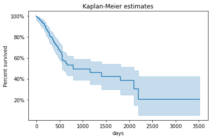

```python
import matplotlib.ticker as mtick

ax = kmf.plot()
ax.set_xlabel('days')
ax.set_ylabel('Probability of survival')
ax.get_legend().remove()
ax.set_title('Kaplan-Meier estimates')
fmt = "%0.0f%%"
ticks = mtick.PercentFormatter(xmax=1,
    symbol='%',
    decimals=None) # formats axis as percents
ax.yaxis.set_major_formatter(ticks)
ax.set_ylabel('Percent survived');

plt.tight_layout();
```